# NO$_2$ Sensor Analysis

Coleman Breen

September 10, 2018

## Analysis and visualization of NO$_2$ in the US

Today we’ll be looking at the presence of NO$_2$ around the UNited States. NO$_2$ is emitted by cars burning fossil fuels. Excess Nitrogen Dioxide causes respiratory issues in humans. It also causes acid rain and can create enough air pollution to make it hard to see. The National Ambient Air Quality Standards say that 100 parts per billion (ppb) is a safe exposure for one hour at a time. This gives us some idea about how much NO$_2$ is too much. You can read more about it [here](https://www.epa.gov/no2-pollution).

We can look at data on NO$_2$ from the [EPA’s website.](https://aqs.epa.gov/aqsweb/airdata/download_files.html) In particular, we are interested in daily NO$_2$ levels for 2017. Later in this analysis, we’ll also pull in O$_3$ data and compare the two pollutants.

```r
#--> Setup environment
knitr::opts_chunk$set(echo = TRUE)
knitr::opts_chunk$set(warning = FALSE)
knitr::opts_chunk$set(message = FALSE)
library(tidyverse)
#--> Load in data
no2_df <- read_csv('data/daily_42602_2017.csv')
names(no2_df)
```

```
##  [1] "State Code"          "County Code"         "Site Num"
##  [4] "Parameter Code"      "POC"                 "Latitude"
##  [7] "Longitude"           "Datum"               "Parameter Name"
## [10] "Sample Duration"     "Pollutant Standard"  "Date Local"
## [13] "Units of Measure"    "Event Type"          "Observation Count"
## [16] "Observation Percent" "Arithmetic Mean"     "1st Max Value"
## [19] "1st Max Hour"        "AQI"                 "Method Code"
## [22] "Method Name"         "Local Site Name"     "Address"
## [25] "State Name"          "County Name"         "City Name"
## [28] "CBSA Name"           "Date of Last Change"
```

```r
#--> Order the variables
no2_df <- select(no2_df, 'State Name', 'City Name', 'AQI', 'Arithmetic Mean', 'Observation Percent',
                 'Observation Count', 'Date Local', 'Latitude', 'Longitude', everything())
names(no2_df)
```

```
##  [1] "State Name"          "City Name"           "AQI"
##  [4] "Arithmetic Mean"     "Observation Percent" "Observation Count"
##  [7] "Date Local"          "Latitude"            "Longitude"
## [10] "State Code"          "County Code"         "Site Num"
## [13] "Parameter Code"      "POC"                 "Datum"
## [16] "Parameter Name"      "Sample Duration"     "Pollutant Standard"
## [19] "Units of Measure"    "Event Type"          "1st Max Value"
## [22] "1st Max Hour"        "Method Code"         "Method Name"
## [25] "Local Site Name"     "Address"             "County Name"
## [28] "CBSA Name"           "Date of Last Change"
```

You can read about what’s in the dataset [here.](https://aqs.epa.gov/aqsweb/airdata/FileFormats.html) A few takeaways:

1. State Code-County Code-Site Num-Parameter Code gives a unique identifier for each individual sensor. There can be multiple sensors with the same State Code-County Code-Site Num.
2. Sample Duration deals with the “length of time that air passes through the monitoring device.”
3. Event Type can include things like wildfires and other things we may/may not want to include in analysis.
4. Arithmetic mean is the average presence of NO$_2$ (in ppb).
5. 1st Max Value gives the highest value of the day.

# How many sensors are measuring NO$_2$?

To answer this question we will have to find how many unique sensore there are. This data set reports information from many sensors and different times of the day.

```r
#--> Create a unique identifier based on state, county codes, and site number
no2_df %>%
  mutate(Identifier = paste(no2_df$'State Code', no2_df$'County Code',
                            no2_df$'Site Num', sep = '-')) -> no2_df

#--> Number of unique sensors
length(unique(no2_df$Identifier))
```

```
## [1] 451
```

There are 451 sensors around the United States measuring NO$_2$.

# How well do these sensors work?

We will do some more manipulation to create a variable telling us what percent of the year each distinct sensor is working. The data report observation percent for individual days. We’ll group these observations by the unique identifier we created earlier and then average their daily working percentage.

```r
#--> Yearly percent that unique sensors are working
no2_df %>%
  group_by(Identifier) %>%
  summarise_at(vars('Observation Percent'), mean) %>%
  ungroup() -> no2_simple_df

#--> Join the unique sensors, yearly percentage, and lat/long
no2_df %>%
  ungroup() %>%
  select('Identifier', 'Latitude', 'Longitude') %>%
  full_join(no2_simple_df, by = 'Identifier') %>%
  distinct() -> no2_simple_df

#--> Rename variable
no2_simple_df <- rename(no2_simple_df, 'YearlyObsPercent' = 'Observation Percent')
head(no2_simple_df)
```

```
## # A tibble: 6 x 4
##   Identifier  Latitude Longitude YearlyObsPercent
##   <chr>          <dbl>     <dbl>            <dbl>
## 1 01-073-0023     33.6     -86.8             90.7
## 2 01-073-2059     33.5     -86.8             89.2
## 3 02-090-0034     64.8    -148.              95.3
## 4 04-013-0019     33.5    -112.              98.5
## 5 04-013-3002     33.5    -112.              98.7
## 6 04-013-4011     33.4    -113.              98.4
```

We’ll plot the distribution of ‘YearlyObsPercent’ to see how the sensors fare.

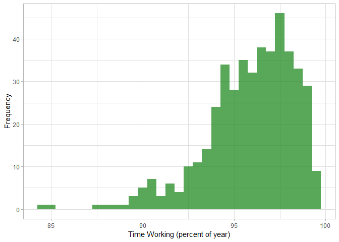

```r
library(ggplot2)

#--> Simple histogram of sensor working percent
ggplot(no2_simple_df, aes(YearlyObsPercent)) +
  geom_histogram(binwidth = .5, fill = 'forestgreen', alpha = .75) +
  theme_light() +
  xlab('Time Working (percent of year)') +
  ylab('Frequency')
```

```r
#--> Summary statisitcs for good measure
summary(no2_simple_df$YearlyObsPercent)
```

```
##    Min. 1st Qu.  Median    Mean 3rd Qu.    Max.
##   84.28   94.53   96.26   95.89   97.67   99.67
```

Sensors seem to be very reliable. Nearly 3 in 4 sensors worked at least 95% of the year 2017. Most work well over 90% of the time.

# Mapping the sensor locations

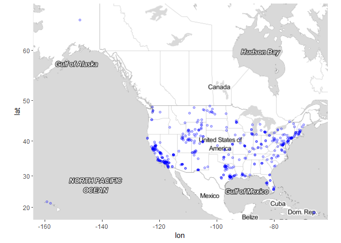

```r
library(ggmap)

#--> Bound the map's coordinates
no2_simple_df %>%
  make_bbox(lat = Latitude, lon = Longitude) -> sensor_bbox

#--> Create and print map
sensor_map <- get_map(location = sensor_bbox, maptype = "toner-lite", zoom = 3)

#--> Overlay sensors
ggmap(sensor_map) +
  geom_point(data = no2_simple_df, mapping = aes(x = Longitude, y = Latitude), color = 'blue', alpha = .25)
```

This gives us some sense of where the sensors are located to begin with. We see a higher concentration around California, Eastern Texas, and New England. There seems to be quite a few in Northern Utah and Wyoming, considering that those areas are not as densley populated.

# Mapping NO$_2$

We’ll now turn our attention towards the presences of Nitrous Dioxide itself. Where is it most densley concentrated?

We don’t have sensor data for each county so we will construct a heat map of the presence of NO$_02$ around the US.

```r
#--> Rename variables so that DPLYR doesn't get tripped up by the spaces
no2_df <- rename(no2_df, 'DailyMeanPPB' = 'Arithmetic Mean')

#--> Compute a yearly average of NO2
no2_df %>%
  group_by(Identifier) %>%
  summarise_at(vars('DailyMeanPPB'), mean) %>%
  ungroup() -> daily_mean_no2_df

#--> Compute a yearly mean AQI
no2_df %>%
  group_by(Identifier) %>%
  summarise_at(vars('AQI'), mean) %>%
  ungroup() -> daily_mean_AQI_df

#--> Join the unique sensors, yearly NO2 ppb, and coordinates
no2_df %>%
  ungroup() %>%
  select('State Name', 'City Name', 'Identifier', 'Latitude', 'Longitude') %>%
  full_join(daily_mean_no2_df, by = 'Identifier') %>%
  distinct() %>%
  full_join(daily_mean_AQI_df) %>%
  distinct() %>%
  rename('DailyMeanAQI' = 'AQI') -> daily_mean_no2_df

rm(daily_mean_AQI_df)

#--> Take a look
head(daily_mean_no2_df, 5)
```

```
## # A tibble: 5 x 7
##   `State Name` `City Name` Identifier Latitude Longitude DailyMeanPPB
##   <chr>        <chr>       <chr>         <dbl>     <dbl>        <dbl>
## 1 Alabama      Birmingham  01-073-00~     33.6     -86.8         9.07
## 2 Alabama      Birmingham  01-073-20~     33.5     -86.8        11.5
## 3 Alaska       Fairbanks   02-090-00~     64.8    -148.         12.5
## 4 Arizona      Phoenix     04-013-00~     33.5    -112.         17.0
## 5 Arizona      Phoenix     04-013-30~     33.5    -112.         18.3
## # ... with 1 more variable: DailyMeanAQI <dbl>
```

We’ve created a data frame that gives us the average daily ppb of NO$_2$ linked to specific coordinates on a map. We’ll create a heat map to visualize the presence of Nitrous Dioxide around the lower 48.

```r
#--> Take out Alaska, Hawaii, Puerto Rico to see trends in the lower 48
remove_states_v = c("Alaska", "Hawaii", "Puerto Rico")

daily_mean_no2_df %>%
  filter(!('State Name' %in% remove_states_v)) %>%
  filter(Longitude > -142) -> daily_mean_no2_df
```

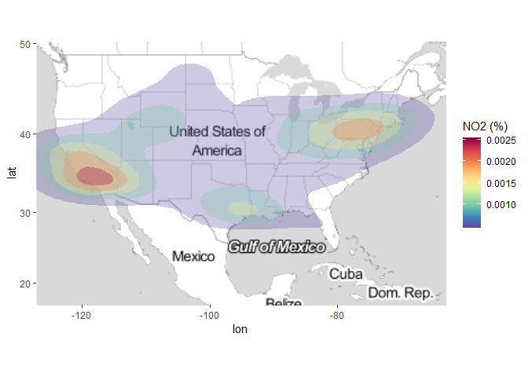

```r
#--> Bound the map's coordinates
daily_mean_no2_df %>%
  make_bbox(lat = Latitude, lon = Longitude) -> no2_box

#--> Create underlying map
no2_map <- get_map(location = no2_box, maptype = "toner-lite", zoom = 3)

#--> Need RColorBrewer
library(RColorBrewer)

#--> Overlay heat map info (NO2)
ggmap(no2_map) +
  stat_density2d(data = daily_mean_no2_df,
             mapping = aes(x = Longitude, y = Latitude, fill =..level..),
             geom = "polygon", alpha = .3) +
  scale_fill_gradientn(name = "NO2 (%)", colours=rev(brewer.pal(10, "Spectral")))
```

```r
#--> Load in libraries
library(sf)
library(leaflet)

#--> Create an sf compatable data type
daily_mean_no2_df <- daily_mean_no2_df[order(daily_mean_no2_df$DailyMeanPPB), ]
daily_mean_no2_sf <- st_as_sf(daily_mean_no2_df, coords = c("Longitude", "Latitude"))

#--> Color spectrum
Npal <- colorNumeric(
  palette = "YlOrRd", n = 10,
  domain = daily_mean_no2_sf$DailyMeanPPB
)

#--> Make our map
no2_circles_map <- daily_mean_no2_sf %>%
  leaflet() %>%
  addProviderTiles(providers$Stamen.TonerLines, group = "Basemap") %>%
  addProviderTiles(providers$Stamen.TonerLite, group = "Basemap") %>%
  addCircles(radius = daily_mean_no2_sf$DailyMeanPPB*5000, fillOpacity = .6,
             fillColor = Npal(daily_mean_no2_sf$DailyMeanPPB), stroke = FALSE) %>%
  addLegend("bottomright", pal = Npal, values = ~DailyMeanPPB,
            labFormat = function(type, cuts, p) {
              n = length(cuts)
              paste0(prettyNum(cuts[-n], digits=0, big.mark = ",", scientific=F),
                     " - ", prettyNum(cuts[-1], digits=0, big.mark=",", scientific=F))},
            title = "Avg. Daily NO2 (ppb)", opacity = 1)

no2_circles_map
```

[interactive chart not shown]

I’m curious to see how similar maps displaying the AQI and O$_3$ in a similar way. We already have the AQI data but let’s load in O$_3$ and take a look at that.

```r
o3_df <- read_csv('data/daily_44201_2017.csv')
```

```r
#--> Create a unique identifier based on state, county codes, and site number
o3_df %>%
  mutate(Identifier = paste(o3_df$'State Code', o3_df$'County Code',
                            o3_df$'Site Num', sep = '-')) -> o3_df

#--> Number of unique sensors
length(unique(o3_df$Identifier))
```

```
## [1] 1265
```

There are 1265 sensors measuring ozone in the US. We’ll do a similar pipeline to what we diw with Nitrous Dioxide to create a map showing where Ozone levels are highest.

```r
#--> Make variable names DPLYR friendly
o3_df <- rename(o3_df, 'DailyMeanPPB' = 'Arithmetic Mean')

#--> Take out Alaska, Hawaii, Puerto Rico
o3_df %>%
  filter(!('State Name' == 'Alaska')) %>%
  filter(!('State Name' == 'Hawaii')) %>%
  filter(!('State Name' == 'Puerto Rico')) %>%
  filter(DailyMeanPPB > .01) %>%
  filter(Longitude > -142) -> o3_df

#--> Compute the yearly mean Ozone
o3_df %>%
  group_by(Identifier) %>%
  summarise_at(vars('DailyMeanPPB'), mean) %>%
  ungroup() -> daily_mean_o3_df

#--> Compute a yearly mean AQI
o3_df %>%
  group_by(Identifier) %>%
  summarise_at(vars('AQI'), mean) %>%
  ungroup() -> daily_mean_AQI_o3_df

#--> Join the unique sensors, yearly NO2 ppb, and coordinates
o3_df %>%
  ungroup() %>%
  select('State Name', 'City Name', 'Identifier', 'Latitude', 'Longitude') %>%
  full_join(daily_mean_o3_df, by = 'Identifier') %>%
  distinct() %>%
  full_join(daily_mean_AQI_o3_df) %>%
  distinct() %>%
  rename('DailyMeanAQI' = 'AQI') -> daily_mean_o3_df

rm(daily_mean_ppb_o3_df, daily_mean_AQI_o3_df)

head(daily_mean_o3_df)
```

```
## # A tibble: 6 x 7
##   `State Name` `City Name` Identifier Latitude Longitude DailyMeanPPB
##   <chr>        <chr>       <chr>         <dbl>     <dbl>        <dbl>
## 1 Alabama      Fairhope    01-003-00~     30.5     -87.9       0.0305
## 2 Alabama      Muscle Sho~ 01-033-10~     34.8     -87.6       0.0266
## 3 Alabama      Crossville  01-049-99~     34.3     -86.0       0.0329
## 4 Alabama      Wetumpka    01-051-00~     32.5     -86.2       0.0228
## 5 Alabama      Southside   01-055-00~     33.9     -86.1       0.0281
## 6 Alabama      Dothan      01-069-00~     31.2     -85.4       0.0255
## # ... with 1 more variable: DailyMeanAQI <dbl>
```

```r
#--> Create an sf compatable data type
daily_mean_o3_df <- daily_mean_o3_df[order(daily_mean_o3_df$DailyMeanPPB), ]
daily_mean_o3_sf <- st_as_sf(daily_mean_o3_df, coords = c("Longitude", "Latitude"))

#--> Color spectrum
Npal2 <- colorNumeric(
  palette = "YlOrRd", n = 10,
  domain = daily_mean_o3_sf$DailyMeanPPB
)

#--> Make our map
o3_circles_map <- daily_mean_o3_sf %>%
  leaflet() %>%
  addProviderTiles(providers$Stamen.TonerLines, group = "Basemap") %>%
  addProviderTiles(providers$Stamen.TonerLite, group = "Basemap") %>%
  addCircles(radius = daily_mean_o3_sf$DailyMeanPPB*2000000, fillOpacity = .6,
             fillColor = Npal2(daily_mean_o3_sf$DailyMeanPPB), stroke = FALSE) %>%
  addLegend("bottomright", pal = Npal2, values = ~DailyMeanPPB,
            labFormat = function(type, cuts, p) {
              n = length(cuts)
              paste0(prettyNum(cuts[-n], digits=0, big.mark = ",", scientific=F),
                     " - ", prettyNum(cuts[-1], digits=0, big.mark=",", scientific=T))},
            title = "Avg. Daily O3 (ppb)", opacity = 1)

o3_circles_map
```

[interactive chart not shown]

We can see that there are many more sensors for Ozone than Nitorus Dioxide. The areas of the country with the worst levels of Ozone are California, Arizona, Utah, Colorado, and Wyoming. For the most part, levels on the East coast and midwest are not as high.

Finally, let’s take a look at AQI.

```r
#--> Color spectrum
Npal3 <- colorNumeric(
  palette = "YlOrRd", n = 10,
  domain = daily_mean_o3_sf$DailyMeanAQI
)

#--> Make our map
aqi_circles_map <- daily_mean_o3_sf %>%
  leaflet() %>%
  addProviderTiles(providers$Stamen.TonerLines, group = "Basemap") %>%
  addProviderTiles(providers$Stamen.TonerLite, group = "Basemap") %>%
  addCircles(radius = daily_mean_o3_sf$DailyMeanPPB*2000000, fillOpacity = .6,
             fillColor = Npal3(daily_mean_o3_sf$DailyMeanAQI), stroke = FALSE) %>%
  addLegend("bottomright", pal = Npal3, values = ~DailyMeanAQI,
            labFormat = function(type, cuts, p) {
              n = length(cuts)
              paste0(prettyNum(cuts[-n], digits=0, big.mark = ",", scientific=F),
                     " - ", prettyNum(cuts[-1], digits=0, big.mark=",", scientific=T))},
            title = "Avg. Daily Air Quality Index", opacity = 1)

aqi_circles_map
```

[interactive chart not shown]

It looks like AQI is the worst in California and still not so great in Arizona, Colorado, and Wyoming. Let’s create a scatter plot with a linear model to look at the correlation between both AQI with Ozone and AQI with Nitrous Dioxide.

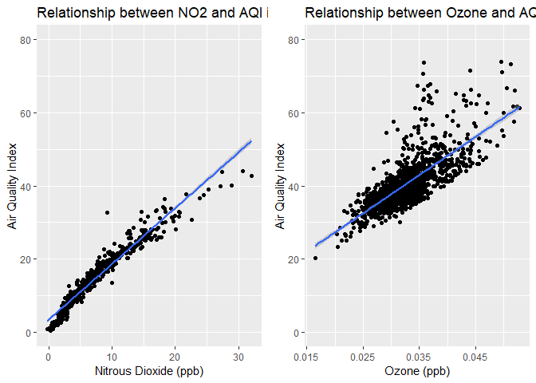

```r
library(gridExtra)

p1 <- ggplot(data = daily_mean_no2_df,
             mapping = aes(x = DailyMeanPPB, y = DailyMeanAQI)) +
  geom_point() +
  geom_smooth(method = 'lm') +
  scale_y_continuous(limits = c(0, 80)) +
  xlab('Nitrous Dioxide (ppb)') +
  ylab('Air Quality Index') +
  ggtitle('Relationship between NO2 and AQI in 2017')

p2 <- ggplot(data = daily_mean_o3_df,
             mapping = aes(x = DailyMeanPPB, y = DailyMeanAQI)) +
  geom_point() +
  geom_smooth(method = 'lm') +
  scale_y_continuous(limits = c(0, 80)) +
  xlab('Ozone (ppb)') +
  ylab('Air Quality Index') +
  ggtitle('Relationship between Ozone and AQI in 2017')

 grid.arrange(p1, p2, nrow = 1)
```

There is a positive relationship for both variables with AQI. NO$_2$ seems to be a stronger predictor of high AQI than O$_3$.